# COVID-19 Concerns on Vaccination Status and Smoking/Drinking Habits on Weight Within HRS Respondents

# R Packages and Setup

```r
library(ROCR)
library(caret)
library(simputation)
library(car)
library(naniar)
library(haven)
library(knitr)
library(rmdformats)
library(here)
library(janitor)
library(magrittr)
library(rms)
library(broom)
library(tidyverse)
```

# 1 1. Data Source

Data is obtained from the [Health and Retirement Study(HRS)](https://hrs.isr.umich.edu/about). HRS is a longitudinal panel study done by the University of Michigan attempting to analyze questions regarding aging. The first HRS interview took place in the year of 1992, and continued every other year. The data used consists of the [2020 HRS Core](https://hrsdata.isr.umich.edu/data-products/2020-hrs-core), which was collected during the period of March 2020 through May 2021.

# 2 2. Subjects

Subjects are individuals born in 1931 through 1941 and were household residents.

# 3 3. Loading and Tidying Data

## 3.1 Loading Raw Data

```r
a_raw <- read_sas("data/a_raw.sas7bdat")
```

## 3.2 Cleaning the Data

### 3.2.1 Cleaning Variables

Removing the old identifiers as I use a new combined identifier based on household ID and person ID, as well as renaming variables to have meaningful names.

```r
a <- a_raw %>%
  rename(weight = RC139,
         binge_drink = RC131,
         depressed = RC150,
         smoke_pday = RC118,
         alc_pwk = RC129,
         vaxxed = RCOVW670,
         cov_concern = RCOVW550,
         cov_death = RCOVW578,
         volunteer = RG086,
         cov_money = RCOVW600,
         spending = RCOVW622,
         cov_known = RCOVW577)
```

Converting variables to appropriate variable types to be used for analysis

```r
a <- a %>%
  mutate(OID = as.character(OID),
         weight = as.numeric(weight),
         binge_drink = as.numeric(binge_drink),
         depressed = as.factor(depressed),
         smoke_pday = as.numeric(smoke_pday),
         alc_pwk = as.numeric(alc_pwk),
         vaxxed = as.factor(vaxxed),
         cov_concern = as.numeric(cov_concern),
         cov_death = as.factor(cov_death),
         volunteer = as.factor(volunteer),
         cov_money = as.numeric(cov_money),
         spending = as.factor(spending),
         cov_known = as.factor(cov_known))
```

```r
a <- a %>%
  mutate(alc_pwk = case_when(alc_pwk < 2  ~ "0-2",
                             alc_pwk < 4 ~ "2-4",
                             alc_pwk < 7 ~ "4-7",
                             alc_pwk < 10 ~ "7-10"),
         alc_pwk = as.factor(alc_pwk))
```

```r
a <- a %>%
  mutate(cov_concern = case_when(cov_concern <= 3 ~ "Hardly concerned",
                                 cov_concern <= 7 ~ "Some Concern",
                                 cov_concern <= 10 ~ "Extreme Concern"),
         cov_concern = as.factor(cov_concern))
```

Recoding the categorical variables to have meaningful values.

```r
a <- a %>%
  mutate(cov_known = fct_recode(cov_known, "yes" = "1",
                                "no" = "5"),
         spending = fct_recode(spending, "up" = "1",
                               "down" = "2",
                               "same" = "3"),
         vaxxed = fct_recode(vaxxed, "no" = "5",
                             "yes" = "1"),
         volunteer = fct_recode(volunteer, "yes" = "1",
                                "no" = "5"),
         cov_death = fct_recode(cov_death, "yes" = "1",
                                "no" = "5"),
         depressed = fct_recode(depressed, "yes" = "1",
                                "no" = "5"))
```

```r
a <- a %>%
  mutate(depressed = na_if(depressed, "8"),
         depressed = na_if(depressed, "9"),
         depressed = na_if(depressed, "3"),
         vaxxed = na_if(vaxxed, "8"),
         cov_death = na_if(cov_death, "8"),
         cov_death = na_if(cov_death, "9"),
         volunteer = na_if(volunteer, "8"),
         cov_known = na_if(cov_known, "8"),
         cov_known = na_if(cov_known, "9"),
         spending = na_if(spending, "8"),
         spending = na_if(spending, "9"),
         binge_drink = na_if(binge_drink, "98"),
         binge_drink = na_if(binge_drink, "99"),
         weight = na_if(weight, "998"),
         weight = na_if(weight, "999"),
         smoke_pday = na_if(smoke_pday, "-8"),
         smoke_pday = na_if(smoke_pday, "98"),
         cov_money = na_if(cov_money, 9999),
         cov_money = na_if(cov_money, 9998)) %>%

  droplevels()
```

### 3.2.2 Sampling data

Since the current data set is over the 1200 observation limit, I chose to slice a random sample of 70% of the data, which also rounds out to close to around 1000 observations. Seed is set as the class number and year.

```r
set.seed(4322022)
a_sample <- a %>%
  slice_sample(., prop = 0.7)
```

Data set does have missing values for some variables. These missing values can be handled with either single imputation or a complete case analysis.

# 4 4. The Tidy Tibble

## 4.1 Listing the Tibble

```r
a_sample
```

```
# A tibble: 996 x 13
   OID       weight binge_drink depressed smoke_pday alc_pwk vaxxed cov_concern
   <chr>      <dbl>       <dbl> <fct>          <dbl> <fct>   <fct>  <fct>
 1 55634010     140          NA no                NA <NA>    no     <NA>
 2 526826010    170          NA no                NA 0-2     no     Some Concern
 3 527182010    186           0 no                NA 0-2     <NA>   Extreme Con~
 4 543462020    100          NA no                NA <NA>    no     Extreme Con~
 5 544497010    197          NA no                NA 0-2     no     Extreme Con~
 6 535112020    161           0 no                10 7-10    <NA>   Extreme Con~
 7 906977010    190           3 no                15 4-7     <NA>   Extreme Con~
 8 914455020    175          20 no                10 7-10    <NA>   Hardly conc~
 9 542810020    250           0 no                 6 0-2     no     Extreme Con~
10 11506010     160          NA no                NA <NA>    no     Extreme Con~
# ... with 986 more rows, and 5 more variables: cov_death <fct>,
#   volunteer <fct>, cov_money <dbl>, spending <fct>, cov_known <fct>
```

## 4.2 Size and Identifier

The tidy data set consists of 996 observations with 13 variables, which includes an identifier variable.

```r
a_sample %>% n_distinct("OID")
```

```
[1] 996
```

## 4.3 Saving the R Data Set

Saving the table as an Rds file.

```r
saveRDS(a_sample, file = "a_sample.Rds")
```

# 5 5. Codebook

The codebook below includes all variables listed within the tidy data set to be used for this project. Descriptions of variables are taken from the codebook of the [HRS website](https://hrs.isr.umich.edu/sites/default/files/meta/2020/core/codebook/h20_00.html), with the original HRS variable name in parentheses for reference. Letters after R refer to the section of the study that the variable is found in.

[output not shown]

## 5.1 Numerical Description

```r
Hmisc::describe(a_sample)
```

```
a_sample

 13  Variables      996  Observations
--------------------------------------------------------------------------------
OID
       n  missing distinct
     996        0      996

lowest : 10059020  10482010  111919021 112432020 112752020
highest: 919600010 919684010 920007020 923525020 959738010
--------------------------------------------------------------------------------
weight
       n  missing distinct     Info     Mean      Gmd      .05      .10
     991        5      164    0.999    176.9    45.81      120      130
     .25      .50      .75      .90      .95
     148      173      200      230      250

lowest :  80  89  90  93  95, highest: 325 330 350 370 380
--------------------------------------------------------------------------------
binge_drink
       n  missing distinct     Info     Mean      Gmd      .05      .10
     660      336       23    0.874    4.236     7.22        0        0
     .25      .50      .75      .90      .95
       0        1        3        6       12

lowest :  0  1  2  3  4, highest: 60 70 80 90 92
--------------------------------------------------------------------------------
depressed
       n  missing distinct
     993        3        2

Value        yes    no
Frequency    262   731
Proportion 0.264 0.736
--------------------------------------------------------------------------------
smoke_pday
       n  missing distinct     Info     Mean      Gmd      .05      .10
     608      388       23    0.979    10.74    7.983        2        3
     .25      .50      .75      .90      .95
       5       10       15       20       20
```

[output cut: 52 more lines]

```
       n  missing distinct
     831      165        3

Value         up  down  same
Frequency    195   134   502
Proportion 0.235 0.161 0.604
--------------------------------------------------------------------------------
cov_known
       n  missing distinct
     833      163        2

Value        yes    no
Frequency    474   359
Proportion 0.569 0.431
--------------------------------------------------------------------------------
```

# 6 6. Linear Regression Plans

How do smoking and drinking habits affect weight in HRS respondents?

## 6.1 My Quantitative Outcome

The linear regression outcome that I am going to use is `weight`. I chose this variable because I was interested in looking for a variable that can be representative of physical health while usually having a good range of values. I also feel like weight is a bit less predictable than other usual quantitative health variables like blood pressure.

```r
a_sample %>%
  filter(complete.cases(weight)) %>%
  summarise(count = n())
```

```
# A tibble: 1 x 1
  count
  <int>
1   991
```

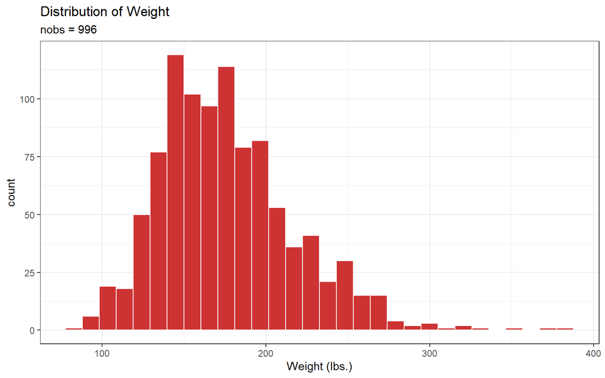

```r
ggplot(a_sample, aes(x = weight)) +
  geom_histogram(col = "white",
                 fill = "brown3") +
  theme_bw() +
  labs(title = "Distribution of Weight",
       subtitle = "nobs = 996",
       x = "Weight (lbs.)")
```

Based on the figure above, it appears that there is right skew for the outcome. Since there appears to only be slight skew that may require a log transformation at most.

## 6.2 My Planned Predictors (Linear Model)

The variables that I have chosen to be my predictors for the linear model are `binge_drink`, `depressed`, `smoke_pday`, and `alc_pwk`

```r
a_sample %>%
  group_by(binge_drink) %>%
  summarise(count = n()) %>%
  arrange(desc(count))
```

```
# A tibble: 24 x 2
   binge_drink count
         <dbl> <int>
 1          NA   336
 2           0   327
 3           1    82
 4           2    77
 5           3    50
 6           4    33
 7           5    23
 8           6    13
 9          90    11
10          10     8
# ... with 14 more rows
```

The multi-categorical variable `alc_pwk` contains 4 categories, each with at least 30 observations.

```r
a_sample %>%
  select(alc_pwk) %>%
  summary()
```

```
 alc_pwk
 0-2 :331
 2-4 :254
 4-7 :106
 7-10: 97
 NA's:208
```

My model has 4 predictors, which is less than (4 + (996-100) / 100)

# 7 7. Logistic Regression Plans

Can we predict vaccination status of HRS respondents based on lifestyle changes resulting from the COVID-19 pandemic?

## 7.1 My Binary Outcome

The name of the binary variable I chose to use as my outcome is `vaxxed`. I wanted to know how the elderly have responded to the COVID-19 pandemic, and what kinds of social pressures play into their decisions on vaccination.

```r
a_sample %>% filter(complete.cases(vaxxed)) %>%
  summarise(count = n())
```

```
# A tibble: 1 x 1
  count
  <int>
1   477
```

## 7.2 My Planned Predictors (Logistic Model)

My planned predictors for the logistic regression model are the variables `cov_concern`, `cov_death`, `volunteer`, `cov_money`, `cov_known` and `spending`

```r
a_sample %>% select(cov_concern) %>%
  summary()
```

```
           cov_concern
 Extreme Concern :551
 Hardly concerned: 88
 Some Concern    :191
 NA's            :166
```

`spending` is a 3-categorical variable with each group having more than 30 observations.

```r
a_sample %>% select(spending) %>%
  summary()
```

```
 spending
 up  :195
 down:134
 same:502
 NA's:165
```

`cov_money` is a quantitative variable with at least 10 unique values.

```r
a_sample %>%
  group_by(cov_money) %>%
  summarise(count = n()) %>%
  arrange(desc(count))
```

```
# A tibble: 47 x 2
   cov_money count
       <dbl> <int>
 1        NA   357
 2      1200   252
 3       600   124
 4      2400   100
 5      1800    54
 6      2000    15
 7      1400    11
 8      3600    11
 9      3000     8
10      1600     5
# ... with 37 more rows
```

# 8 8: Linear Regression Analysis

```r
a_linear <- a_sample %>%
  select(OID, weight, binge_drink, depressed, smoke_pday, alc_pwk) %>%
  filter(complete.cases(weight))

a_linear
```

```
# A tibble: 991 x 6
   OID       weight binge_drink depressed smoke_pday alc_pwk
   <chr>      <dbl>       <dbl> <fct>          <dbl> <fct>
 1 55634010     140          NA no                NA <NA>
 2 526826010    170          NA no                NA 0-2
 3 527182010    186           0 no                NA 0-2
 4 543462020    100          NA no                NA <NA>
 5 544497010    197          NA no                NA 0-2
 6 535112020    161           0 no                10 7-10
 7 906977010    190           3 no                15 4-7
 8 914455020    175          20 no                10 7-10
 9 542810020    250           0 no                 6 0-2
10 11506010     160          NA no                NA <NA>
# ... with 981 more rows
```

## 8.1 Missingness

A missing variable summary is ran to see the number and percentage of missing values for each predictor. The highest that we see is the variable `smoke_pday` with 386 missing values, or 38.95%. Assuming MCAR and applying complete cases would drastically bias the results, and it is more realistic to assume MAR and use imputation. Because of the amount of missingness, I am going to use multiple imputation.

```r
miss_var_summary(a_linear)
```

```
# A tibble: 6 x 3
  variable    n_miss pct_miss
  <chr>        <int>    <dbl>
1 smoke_pday     386   39.0
2 binge_drink    334   33.7
3 alc_pwk        206   20.8
4 depressed        3    0.303
5 OID              0    0
6 weight           0    0
```

## 8.2 Outcome Transformation

First I am going to look at the outcome variable `weight` using a boxCox and a histogram. This will let me observe the distribution and any recommended transformations based on a model.

[figure not shown]

```r
ggplot(a_linear, aes(x = weight)) +
  geom_histogram(col = "white",
                 fill = "brown3") +
  theme_bw() +
  labs(title = "Distribution of Weight",
       subtitle = "nobs = 986",
       x = "Weight (lbs.)")
```

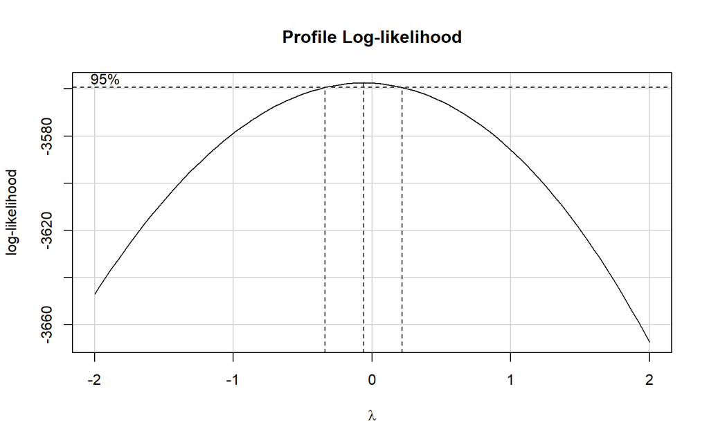

```r
a_linear %$%
  boxCox(weight ~ binge_drink + depressed + alc_pwk + smoke_pday)
```

The histogram above shows some right skew with a few potential minor outliers. The boxCox utilizes the main effects model and appears to suggest a log transformation.

[figure not shown]

```r
ggplot(a_linear, aes(x = log(weight))) +
  geom_histogram(col = "white",
                 fill = "brown3") +
  theme_bw() +
  labs(title = "Distribution of Weight",
       subtitle = "nobs = 986",
       x = "Weight (lbs.)")
```

After looking at a histogram of the log of weight, It looks like a normal distribution. I am satisfied with this and will continue with the outcome variable being a log transformation of `weight`. I will simply add a variable to the data that is `wt_log`.

```r
a_linear <- a_linear %>%
  mutate(wt_log = log(weight))
```

## 8.3 Scatterplot Matrix And Collinearity

Before performing the scatterplot matrix, I know my dataset has a good amount of missingness. I plan on performing multiple imputation for the actual analysis, however I am going to use single imputation in developing the scatterplot matrix so I do not have to build an unnecessary amount of matrices.

```r
set.seed(432)

linear_si <- a_linear %>%
  filter(complete.cases(depressed)) %>%
  impute_rlm(smoke_pday ~  depressed) %>%
  impute_rlm(binge_drink ~  depressed + smoke_pday) %>%
  impute_cart(alc_pwk ~ binge_drink + depressed) %>%
  tibble()
```

After I perform the imputation, I do a quick missing variable summary to make sure the imputation was performed properly.

```r
miss_var_summary(linear_si)
```

```
# A tibble: 7 x 3
  variable    n_miss pct_miss
  <chr>        <int>    <dbl>
1 OID              0        0
2 weight           0        0
3 binge_drink      0        0
4 depressed        0        0
5 smoke_pday       0        0
6 alc_pwk          0        0
7 wt_log           0        0
```

A scatterplot matrix of the variables is observed to look at correlation. The greatest value seen is 0.176 between the variables `binge_drink` and `smoke_pday`. However, this value only suggests a minor positive correlation. I don’t necessarily see anything that sticks out, so I am comfortable running all of these variables together in a main effects model.

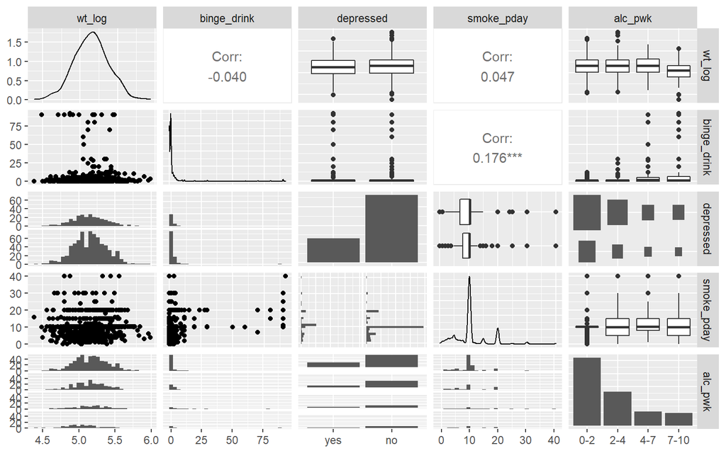

```r
GGally::ggpairs(linear_si %>%
                  select(wt_log, binge_drink, depressed, smoke_pday, alc_pwk))
```

## 8.4 Model A

The first model that is developed is the main effects model. this model is going to be developed using multiple imputation. Since there is a good amount of missingness, I am going to do more than the default amount of imputations. A model for the imputation is stored and used in developing the main effects model.

```r
set.seed(432)
dd <- datadist(a_linear)
options(datadist = "dd")

fit_imp <- aregImpute(~ alc_pwk + binge_drink  + smoke_pday + depressed,
                      data = a_linear,  nk = 0, B = 10, n.impute = 20)
```

[output not shown]

```r
m1ols <- fit.mult.impute(wt_log ~ alc_pwk + binge_drink + smoke_pday + depressed,
                         fitter = ols, xtrans = fit_imp,
                         data = a_linear, pr=  FALSE, x = TRUE, y = TRUE)
```

### 8.4.1 Coefficients

A tidied table of the coefficients is displayed.

```r
kable(coef(m1ols), digits = 4)
```

|  | x |
| --- | --- |
| Intercept | 5.1333 |
| alc_pwk=2-4 | -0.0064 |
| alc_pwk=4-7 | -0.0208 |
| alc_pwk=7-10 | -0.1080 |
| binge_drink | 0.0000 |
| smoke_pday | 0.0017 |
| depressed=no | 0.0210 |

### 8.4.2 Summary Statistics

Validate is performed on the model to do resampling and obtain a validated R-square statistic. The models test R-square is about half of the training R-square, and results in an index.corrected value of 0.01

```r
validate(m1ols)
```

```
          index.orig training   test optimism index.corrected  n
R-square      0.0241   0.0291 0.0175   0.0116          0.0125 40
MSE           0.0519   0.0516 0.0523  -0.0006          0.0525 40
g             0.0355   0.0367 0.0314   0.0053          0.0302 40
Intercept     0.0000   0.0000 0.5617  -0.5617          0.5617 40
Slope         1.0000   1.0000 0.8909   0.1091          0.8909 40
```

Here I obtain the AIC and BIC values for the model to assess fit quality.

```r
AIC(m1ols)
```

```
    d.f.
-103.153
```

```r
BIC(m1ols)
```

```
     d.f.
-63.96328
```

### 8.4.3 Residual Plots

Residual plots cannot be obtained for the imputed model, so I can pull out a specific imputation and store it as a dataset to observe residual plots. For this case, I chose to look at the 3rd imputation.

```r
imputed_3 <-
  impute.transcan(fit_imp, data = a_linear, imputation = 3,
                  list.out = T, pr = F, check = F)

imputed_df3 <- as.data.frame(do.call(cbind, imputed_3))

third_imp <-
  bind_cols(oid = a_linear$OID, wt_log = a_linear$wt_log, imputed_df3) %>%
  type.convert(as.is = FALSE) %>% tibble()
```

A model is made for the residual plots of the third imputation

```r
mod_resid_plots <- lm(wt_log ~ alc_pwk + binge_drink + depressed +smoke_pday, data = third_imp)
```

The glance function from the `broom` package shows the r.squared, AIC, and BIC from this specific imputation. This table indicates the model does not account for a lot of variation, with an r.squared value of 0.024.

```r
broom::glance(mod_resid_plots) %>%
  select(r.squared, adj.r.squared, AIC, BIC, nobs, df, df.residual) %>%
  kable(digits = 3)
```

| r.squared | adj.r.squared | AIC | BIC | nobs | df | df.residual |
| --- | --- | --- | --- | --- | --- | --- |
| 0.024 | 0.02 | -106.969 | -77.577 | 991 | 4 | 986 |

Residual plots for the third imputation are displayed. Based on all of the plots below, I cannot see anything that appears out of the ordinary or that would be willing to go into further detail for. There is a large conglomeration of very low leverage observations, however the greatest leverage value is still below 0.06.

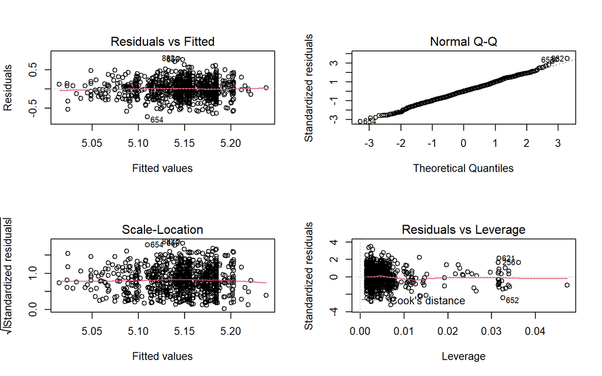

```r
par(mfrow = c(2,2))
plot(mod_resid_plots)
```

```r
par(mfrow=c(1,1))
```

## 8.5 Non-linearity

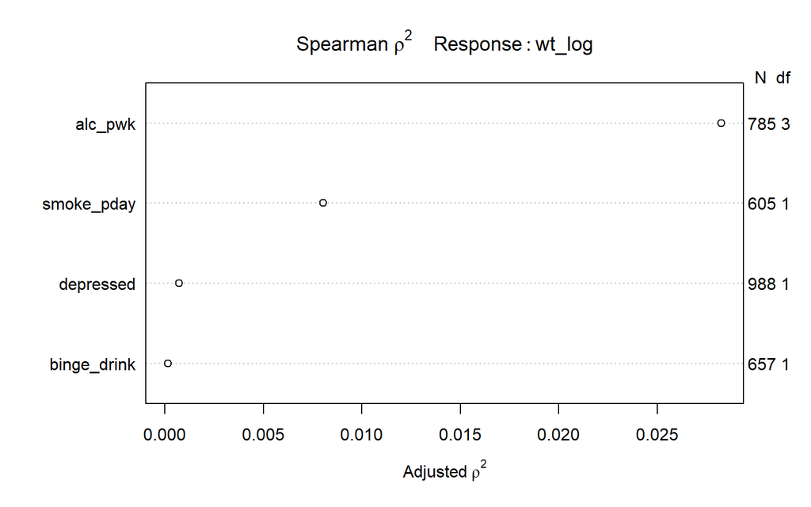

```r
a_linear %$%
  plot(spearman2(wt_log ~ alc_pwk + smoke_pday + binge_drink + depressed))
```

## 8.6 Model B

Again, I am going to do multiple imputation for the augmented model. This model is going to include an interaction term between `alc_pwk` and `smoke_pday`, as well as between `alc_pwk` and `depressed`.

```r
set.seed(432)
dd <- datadist(a_linear)
options(datadist = "dd")

fit_imp2 <- aregImpute(~ alc_pwk + binge_drink  + smoke_pday + depressed,
                      data = a_linear,  nk = c(0, 4), tlinear = FALSE, B = 10, n.impute = 25, x = TRUE)
```

[output not shown]

```r
m2ols <-
  fit.mult.impute(wt_log ~ binge_drink + alc_pwk * depressed + smoke_pday + alc_pwk %ia% smoke_pday,
                  fitter = ols, xtrans = fit_imp2,
                  data = a_linear, pr = FALSE, x = TRUE, y = TRUE)
```

### 8.6.1 ANOVA

```r
anova(m2ols)
```

```
                Analysis of Variance          Response: wt_log

 Factor                                              d.f. Partial SS
 binge_drink                                           1   0.005956611
 alc_pwk  (Factor+Higher Order Factors)                9   0.951702120
  All Interactions                                     6   0.101790087
 depressed  (Factor+Higher Order Factors)              4   0.121682835
  All Interactions                                     3   0.038886012
 smoke_pday  (Factor+Higher Order Factors)             4   0.133048344
  All Interactions                                     3   0.067285410
 alc_pwk * smoke_pday  (Factor+Higher Order Factors)   3   0.067285410
 alc_pwk * depressed  (Factor+Higher Order Factors)    3   0.038886012
 TOTAL INTERACTION                                     6   0.101790087
 REGRESSION                                           12   1.166077800
 ERROR                                               978  51.114940734
 MS          F    P
 0.005956611 0.11 0.7357
 0.105744680 2.02 0.0340
 0.016965014 0.32 0.9243
 0.030420709 0.58 0.6757
 0.012962004 0.25 0.8628
 0.033262086 0.64 0.6366
 0.022428470 0.43 0.7322
 0.022428470 0.43 0.7322
 0.012962004 0.25 0.8628
 0.016965014 0.32 0.9243
 0.097173150 1.86 0.0356
 0.052264766
```

### 8.6.2 Nomogram

Plotted below is a nomogram for the augmented linear regression model. We can see a large variation in the point contribution depending on the interaction of the terms. The nomogram splits the variable `smoke_pday` into different lines based on what groups the observation belongs to for `alc_pwk` and `depressed`. The two lines associated with having 0-2 drinks of alcohol per week are associated with the highest range of point contribution. The lowest is the appears to be when an individual has 7-10 drinks per week. This is interesting, suggesting that when including an interaction term with smoking per day and depressive status, individuals weigh more with a fewer amount of alcoholic drinks per week.

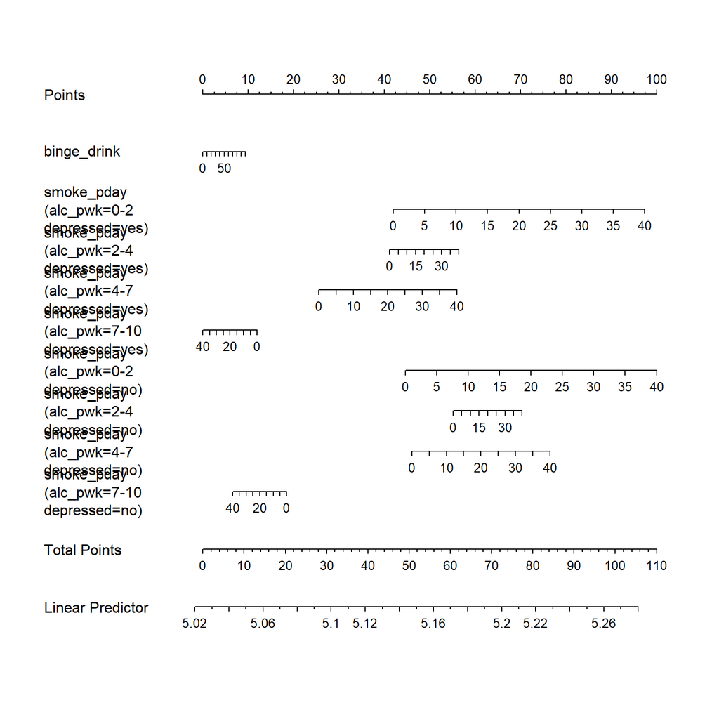

```r
plot(nomogram(m2ols))
```

Below is the augmented models plot of effects. The only variable whose confidence interval does not pass 0 for this plot is `alc_pwk`. When changing alcohol consumption per week from the ‘0-2’ group to the ‘7-10’ group, the log of weight decreases by about 0.10. `alc_pwk` is an ordinal categorical variable that is based on numeric values, and this effect size indicates the most extreme change in category.

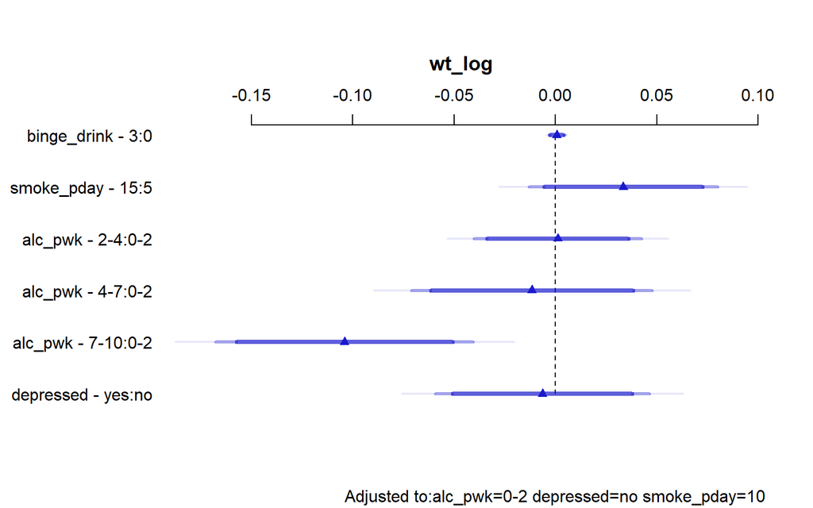

```r
plot(summary(m2ols))
```

A residual vs. fitted plot is shown below. Although it does not appear to be a major concern, there does seem to be almost a separation at the 5.08 mark.

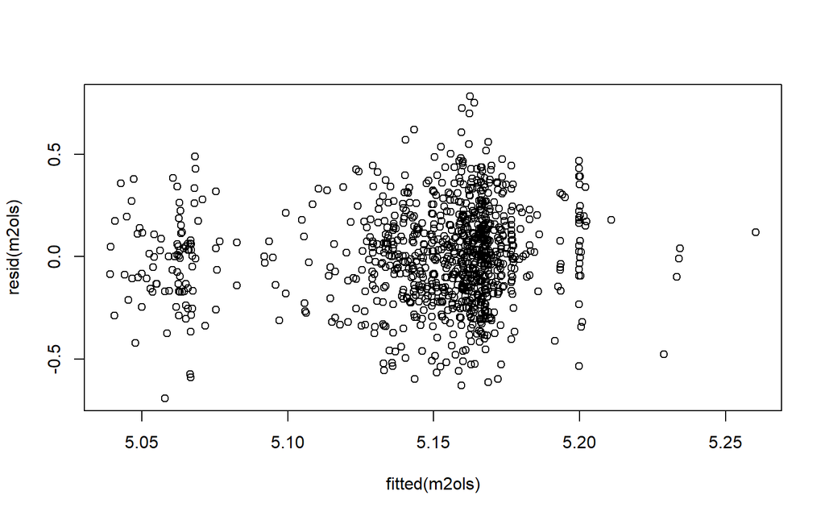

```r
plot(resid(m2ols) ~ fitted(m2ols))
```

## 8.7 Model Validation

Below the validate() function is performed and a table of summary statistics is shown. The main effects model appears to have performed better on test sets, with a higher test r-square value and a higher index corrected R-square. Both models show a similar MSE for both test sets and index corrected.

```r
set.seed(432)
validate(m1ols, method = "boot", B = 40)
```

```
          index.orig training   test optimism index.corrected  n
R-square      0.0241   0.0312 0.0162   0.0150          0.0091 40
MSE           0.0519   0.0508 0.0523  -0.0016          0.0535 40
g             0.0355   0.0383 0.0311   0.0072          0.0283 40
Intercept     0.0000   0.0000 0.7705  -0.7705          0.7705 40
Slope         1.0000   1.0000 0.8506   0.1494          0.8506 40
```

```r
validate(m2ols, method = "boot", B = 40)
```

```
          index.orig training   test optimism index.corrected  n
R-square      0.0249   0.0364 0.0135   0.0229          0.0020 40
MSE           0.0519   0.0508 0.0525  -0.0016          0.0535 40
g             0.0416   0.0441 0.0315   0.0126          0.0290 40
Intercept     0.0000   0.0000 1.3918  -1.3918          1.3918 40
Slope         1.0000   1.0000 0.7297   0.2703          0.7297 40
```

## 8.8 Final Model

When considering both models, I think it is important to consider that both models do not appear to perform well. Neither model appears to account for more than 5% of variation, and this number decreases when using bootstrapped test data. As such, I do not feel that incorporating the additional 6 degrees of freedom is worthwhile so I would prefer the simpler main effects model.

Below will show a summary of the effect sizes for the main effects model as well as a plot for the effect sizes.

```r
summary(m1ols)
```

```
             Effects              Response : wt_log

 Factor             Low High Diff. Effect      S.E.      Lower 0.95 Upper 0.95
 binge_drink        0    3    3     5.2045e-05 0.0019507 -0.0037760  0.0038801
 smoke_pday         5   15   10     1.6531e-02 0.0123020 -0.0076093  0.0406710
 alc_pwk - 2-4:0-2  1    2   NA    -6.3920e-03 0.0184630 -0.0426240  0.0298400
 alc_pwk - 4-7:0-2  1    3   NA    -2.0771e-02 0.0244320 -0.0687150  0.0271740
 alc_pwk - 7-10:0-2 1    4   NA    -1.0804e-01 0.0277550 -0.1625100 -0.0535730
 depressed - yes:no 2    1   NA    -2.0973e-02 0.0167170 -0.0537780  0.0118320
```

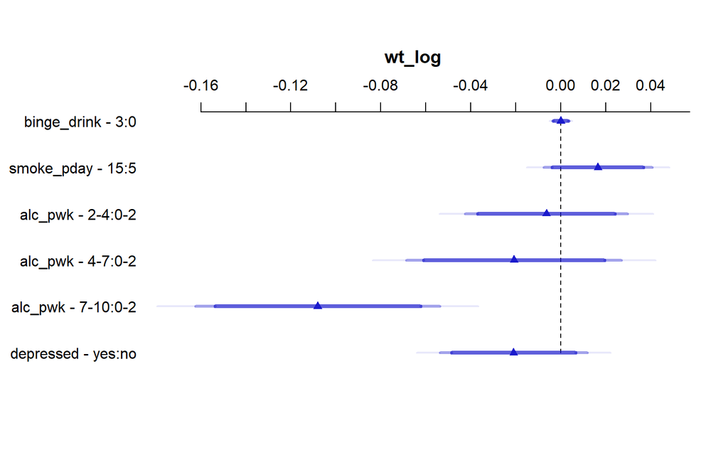

```r
plot(summary(m1ols))
```

Based on the figures above, the effect change when going from 0-2 drinks per week to 7-10 drinks per week appears significant. Assuming all other variables are held constant, when changing `alc_pwk` groups from 0-2 to 7-10, the log of weight decreases by 0.11, with a 95% confidence interval (-0.16, -0.06). Based on this data, it could be that only larger changes in drinking habits are noticeable on affecting weight.

```r
set.seed(432)
validate(m1ols, method = "boot", B = 40)
```

```
          index.orig training   test optimism index.corrected  n
R-square      0.0241   0.0312 0.0162   0.0150          0.0091 40
MSE           0.0519   0.0508 0.0523  -0.0016          0.0535 40
g             0.0355   0.0383 0.0311   0.0072          0.0283 40
Intercept     0.0000   0.0000 0.7705  -0.7705          0.7705 40
Slope         1.0000   1.0000 0.8506   0.1494          0.8506 40
```

Code below creates a nomogram, and then creates a prediction for a mock observation. This model appears to indicate that binge drinking has essentially no effect on the log of weight. We can also observe a dramatic shift in points for the `alc_pwk` variable from ‘7-10’ to ‘4-7’.

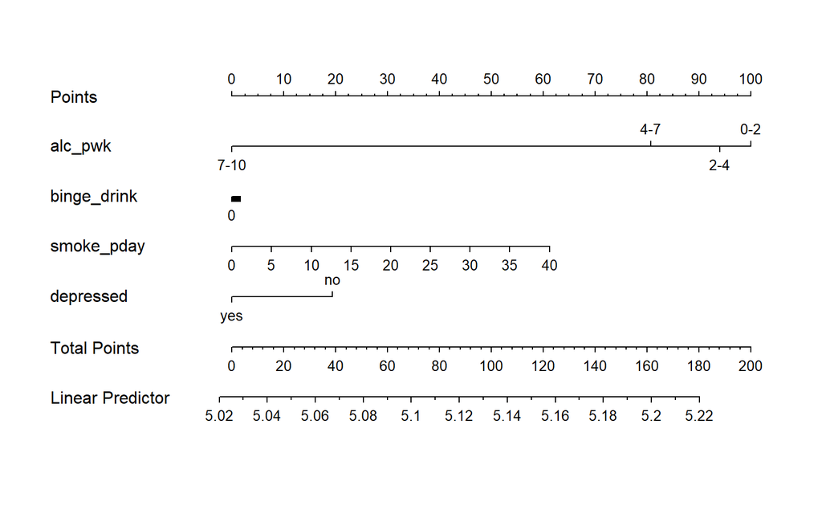

```r
plot(nomogram(m1ols))
```

A prediction is ran below for an individual that is not depressed but partakes in drinking and smoking. This individual is in the ‘7-0’ category for `alc_pwk`, attributing 0 points here. The binge drink variable is negligible, a `smoke_pday` value of 10 seems to contribute about 17 points, and not being depressed contributes about 20 points. This comes out to a log(weight) prediction of about 5.06, which is a weight value of 158.07 lbs.

```r
predict(m1ols,
        expand.grid(alc_pwk = "7-10", binge_drink = 16, smoke_pday = 10, depressed = "no"),
        conf.int = 0.95, conf.type = "individual") %>% as.data.frame() %>%
  mutate(linear_exp = exp(linear.predictors),
         lower_exp = exp(lower),
         upper_exp = exp(upper))
```

```
  linear.predictors    lower    upper linear_exp lower_exp upper_exp
1          5.063072 4.612461 5.513683   158.0754  100.7317   248.063
```

# 9 9: Logistic Regression

My first step is to create the data set for the logistic regression analysis. I am going to select the specified variables for the model and utilize complete cases for the outcome variable.

```r
a_log <- a_sample %>%
  select(OID, vaxxed, cov_concern, cov_death, cov_money, volunteer, spending, cov_known) %>%
  filter(complete.cases(vaxxed))


a_log
```

```
# A tibble: 477 x 8
   OID       vaxxed cov_concern cov_death cov_money volunteer spending cov_known
   <chr>     <fct>  <fct>       <fct>         <dbl> <fct>     <fct>    <fct>
 1 55634010  no     <NA>        no               NA no        <NA>     no
 2 526826010 no     Some Conce~ no              600 no        same     yes
 3 543462020 no     Extreme Co~ no             1200 no        same     no
 4 544497010 no     Extreme Co~ no             1800 no        same     no
 5 542810020 no     Extreme Co~ yes            3600 no        same     yes
 6 11506010  no     Extreme Co~ yes            1200 no        up       yes
 7 211530020 no     Extreme Co~ yes             600 no        down     yes
 8 915067010 no     Extreme Co~ yes             600 no        up       yes
 9 902409010 yes    Extreme Co~ yes            2000 no        same     yes
10 529253020 no     Hardly con~ yes            1200 yes       same     yes
# ... with 467 more rows
```

## 9.1 Missingness

```r
miss_var_summary(a_log)
```

```
# A tibble: 8 x 3
  variable    n_miss pct_miss
  <chr>        <int>    <dbl>
1 cov_money       52   10.9
2 cov_concern      3    0.629
3 cov_death        2    0.419
4 volunteer        2    0.419
5 spending         1    0.210
6 cov_known        1    0.210
7 OID              0    0
8 vaxxed           0    0
```

```r
a_log <- a_log %>%
  filter(complete.cases(cov_concern, cov_death, volunteer, spending, cov_known))
```

```r
miss_var_summary(a_log)
```

```
# A tibble: 8 x 3
  variable    n_miss pct_miss
  <chr>        <int>    <dbl>
1 cov_money       50     10.7
2 OID              0      0
3 vaxxed           0      0
4 cov_concern      0      0
5 cov_death        0      0
6 volunteer        0      0
7 spending         0      0
8 cov_known        0      0
```

This leaves me with only missing data for `cov_money` on slightly more than 10% of observations. Because this is not a large amount, I will go through this analysis using single imputation.

For performing single imputation, I first create a table using the bind_shadow() function to help with working with missing data. From the simputation package I use the `impute_rlm()` function for the continous variable `cov_money`, with a model using `cov_concern` + `cov_death` + `volunteer` as predictors.

```r
a_log_sh <- bind_shadow(a_log)

a_log_sh <- a_log_sh %>%
  data.frame() %>%
  impute_rlm(., cov_money ~ cov_concern + cov_death + volunteer) %>%
  tibble()

a_log_sh <- a_log_sh %>%
  select(OID, vaxxed, cov_concern, cov_death, cov_money, volunteer, cov_known, spending)
```

```r
miss_var_summary(a_log_sh)
```

```
# A tibble: 8 x 3
  variable    n_miss pct_miss
  <chr>        <int>    <dbl>
1 OID              0        0
2 vaxxed           0        0
3 cov_concern      0        0
4 cov_death        0        0
5 cov_money        0        0
6 volunteer        0        0
7 cov_known        0        0
8 spending         0        0
```

## 9.2 Model Y

Here I am creating the first model for the logistic regression, the main effects model. This model will use 6 variables collected in the covid section of the HRS survey. The model is fit using `lrm()`.

```r
d <- datadist(a_log_sh)
options(datadist ="d")

m1lrm <- lrm(vaxxed ~ cov_concern + cov_death + cov_money + volunteer + cov_known + spending,
             data = a_log_sh, x = T, y = T)

m1glm <- glm(vaxxed ~ cov_concern + cov_death + cov_money + volunteer + cov_known + spending,
             data = a_log_sh, family = "binomial")
```

A model is also fit using `glm()` for its ease of use with certain summary statistics later on.

### 9.2.1 Regression Coefficients

A tidy table of the regression coefficients is shown.

```r
kable(coef(m1lrm), digits = 4)
```

|  | x |
| --- | --- |
| Intercept | 0.5136 |
| cov_concern=Hardly concerned | 0.9366 |
| cov_concern=Some Concern | 0.5934 |
| cov_death=no | 0.1572 |
| cov_money | 0.0000 |
| volunteer=no | 0.1480 |
| cov_known=no | 0.0595 |
| spending=down | -0.4087 |
| spending=same | -0.0451 |

Below shows the `lrm` output, with information about the model as well as summary statistics. The model shows a Nagelkerke R-squared of 0.041, and a C-statistic of 0.610. In terms of model strength, these values do not suggest that the model is of pretty poor quality. The ‘variable ’Some concern’ and ‘Hardly concerned’ category for the variable `cov_concern` appear to have statistical significance at the alpha = 0.05 level.

```r
m1lrm
```

```
Logistic Regression Model

 lrm(formula = vaxxed ~ cov_concern + cov_death + cov_money +
     volunteer + cov_known + spending, data = a_log_sh, x = T,
     y = T)

                       Model Likelihood    Discrimination    Rank Discrim.
                             Ratio Test           Indexes          Indexes
 Obs           469    LR chi2     13.81    R2       0.041    C       0.610
  yes          144    d.f.            8    g        0.434    Dxy     0.221
  no           325    Pr(> chi2) 0.0870    gr       1.544    gamma   0.222
 max |deriv| 2e-07                         gp       0.088    tau-a   0.094
                                           Brier    0.206

                              Coef    S.E.   Wald Z Pr(>|Z|)
 Intercept                     0.5136 0.3561  1.44  0.1492
 cov_concern=Hardly concerned  0.9366 0.4119  2.27  0.0230
 cov_concern=Some Concern      0.5934 0.2539  2.34  0.0194
 cov_death=no                  0.1572 0.2141  0.73  0.4628
 cov_money                     0.0000 0.0001 -0.19  0.8484
 volunteer=no                  0.1480 0.2524  0.59  0.5575
 cov_known=no                  0.0595 0.2375  0.25  0.8022
 spending=down                -0.4087 0.3204 -1.28  0.2022
 spending=same                -0.0451 0.2523 -0.18  0.8580
```

### 9.2.2 Nomogram

A nomogram is shown below for the model. One factor of this plot that is of note is the extreme difference in points assigned for he `cov_concern` variable, with the ‘extreme concern’ category contributing 0 points and the ‘hardly concerned’ category contributing 100 points. This also tells me that lower concern appears to increase the probability that someone has received the covid-19 vaccination.

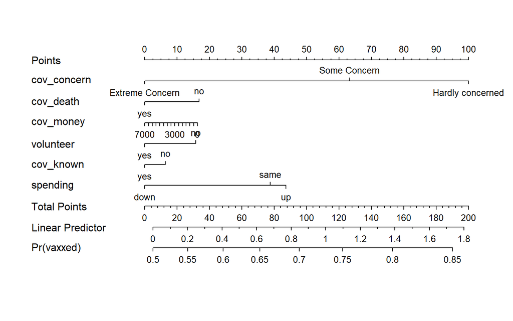

```r
plot(nomogram(m1lrm, fun = plogis,
              funlabel = "Pr(vaxxed)"))
```

### 9.2.3 Confusion Matrix

Here I am augmenting the glm model in order to fit a confusion matrix.

```r
m1glm_aug <- augment(m1glm, a_log_sh,
                     type.predict ="response")
```

```r
Hmisc::describe(m1glm_aug$.fitted)
```

```
m1glm_aug$.fitted
       n  missing distinct     Info     Mean      Gmd      .05      .10
     469        0      231        1    0.693  0.08762   0.5617   0.6052
     .25      .50      .75      .90      .95
  0.6435   0.6815   0.7656   0.8023   0.8294

lowest : 0.5066645 0.5153624 0.5164491 0.5197082 0.5229657
highest: 0.8502352 0.8509920 0.8511622 0.8528083 0.8535551
```

```r
m1glm_aug %$%
  confusionMatrix(
    data = factor(.fitted >= 0.70),
    reference = factor(vaxxed == "yes"),
    positive = "TRUE")
```

```
Confusion Matrix and Statistics

          Reference
Prediction FALSE TRUE
     FALSE   199  112
     TRUE    126   32

               Accuracy : 0.4925
                 95% CI : (0.4464, 0.5388)
    No Information Rate : 0.693
    P-Value [Acc > NIR] : 1.0000

                  Kappa : -0.1611

 Mcnemar's Test P-Value : 0.3994

            Sensitivity : 0.22222
            Specificity : 0.61231
         Pos Pred Value : 0.20253
         Neg Pred Value : 0.63987
             Prevalence : 0.30704
         Detection Rate : 0.06823
   Detection Prevalence : 0.33689
      Balanced Accuracy : 0.41726

       'Positive' Class : TRUE
```

Using the above criteria, the confusion matrix produced an accuracy of 49.25%. This is not indicative of any strong predictive value. Sensitivity of 22.2% indicates that when a person is actually vaccinated, this model will be correct in predicting it only 22.2% of the time, which is extremely low. The specificity of 0.61 indicates that if a person is not vaccinated, the model will predict this correctly only 61% of the time. This is also an extremely low value for specificity.

## 9.3 Non-Linearity

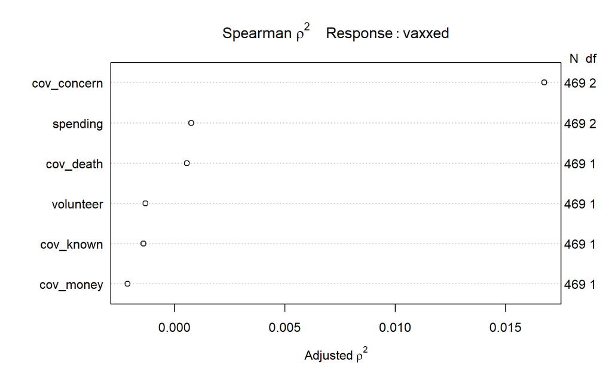

```r
plot(spearman2(vaxxed ~ cov_concern + cov_death + volunteer + cov_money + spending + cov_known, data = a_log_sh))
```

## 9.4 Model Z

```r
dd <- datadist(a_log_sh)
options(datadist = "dd")

m2lrm <- lrm(vaxxed ~ cov_concern + cov_money + cov_death + volunteer + spending + cov_known + cov_concern %ia% spending,
             data = a_log_sh, x = T, y = T)


m2glm <- glm(vaxxed ~ cov_concern + cov_death + cov_money + volunteer + cov_concern %ia% cov_money, data = a_log_sh,
             family = "binomial"(link="logit"))
```

```r
m2lrm
```

```
Logistic Regression Model

 lrm(formula = vaxxed ~ cov_concern + cov_money + cov_death +
     volunteer + spending + cov_known + cov_concern %ia% spending,
     data = a_log_sh, x = T, y = T)

                     Model Likelihood    Discrimination    Rank Discrim.
                           Ratio Test           Indexes          Indexes
 Obs         469    LR chi2     19.30    R2       0.057    C       0.620
  yes        144    d.f.           12    g        0.615    Dxy     0.240
  no         325    Pr(> chi2) 0.0816    gr       1.849    gamma   0.242
 max |deriv|   1                         gp       0.095    tau-a   0.102
                                         Brier    0.205

                                              Coef    S.E.    Wald Z Pr(>|Z|)
 Intercept                                     0.3802  0.3674  1.03  0.3008
 cov_concern=Hardly concerned                  1.9008  1.0730  1.77  0.0765
 cov_concern=Some Concern                      1.0437  0.6794  1.54  0.1245
 cov_money                                     0.0000  0.0001 -0.14  0.8865
 cov_death=no                                  0.1463  0.2155  0.68  0.4973
 volunteer=no                                  0.1585  0.2543  0.62  0.5332
 spending=down                                -0.3440  0.3689 -0.93  0.3510
 spending=same                                 0.1404  0.2863  0.49  0.6239
 cov_known=no                                  0.0818  0.2381  0.34  0.7312
 cov_concern=Hardly concerned * spending=down  6.3128 30.0248  0.21  0.8335
 cov_concern=Hardly concerned * spending=same -1.5296  1.1661 -1.31  0.1896
 cov_concern=Some Concern * spending=down     -0.4988  0.8651 -0.58  0.5642
 cov_concern=Some Concern * spending=same     -0.5543  0.7493 -0.74  0.4594
```

Below is a visual plot for the effect sizes of the augmented model. This plot looks at the effects as odds ratios. Based on the plot below, it seems that every effect shown has a confidence interval that contains an odds ratio of 1.00. Although not statistically significant, being somewhat concerned has slightly above 1.6 times the odds of being vaccinated versus being extremely concerned.

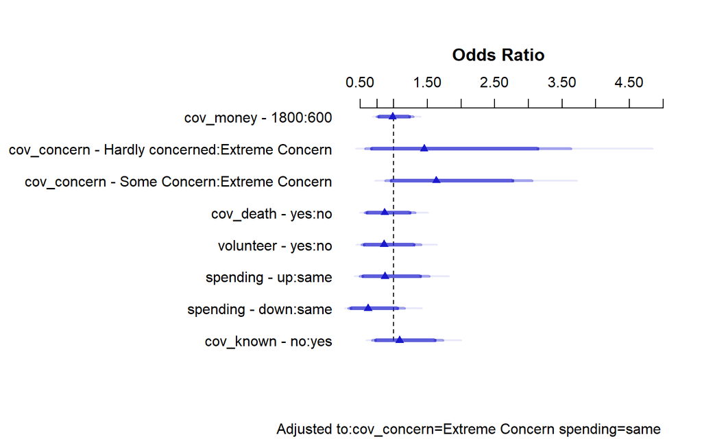

```r
plot(summary(m2lrm))
```

### 9.4.1 Nomogram

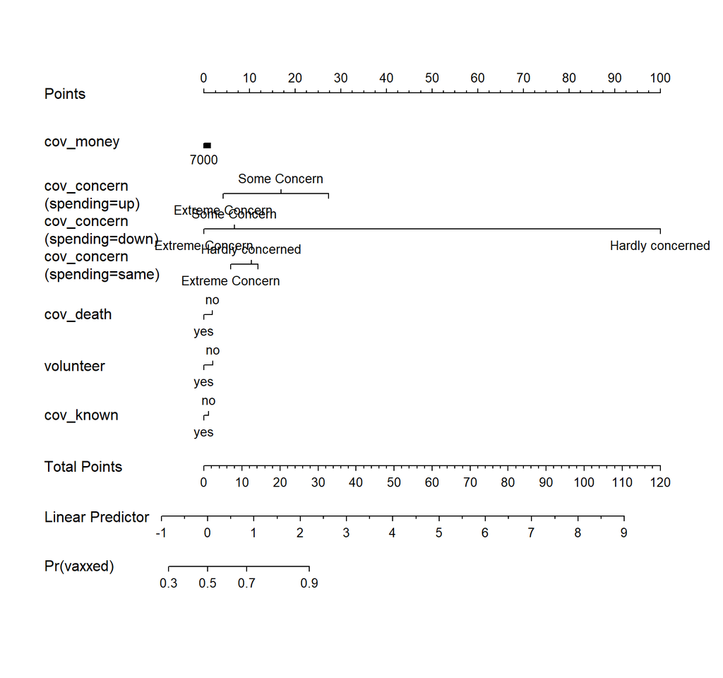

```r
plot(nomogram(m2lrm, fun = plogis,
              fun.at = c(seq(0.3, 2.0, by = 0.2)),
              funlabel = "Pr(vaxxed)"))
```

The plot above is the nomogram for the augmented model, including a probability of being vaccinated. Based on the visualization above, the combination of being hardly concerned about covid-19 and decreased spending is a heavy contributor to probability of being vaccinated. We can also see that the continuous variable `cov_money` does not contribute much to the point total.

### 9.4.2 ANOVA

```r
anova(m2lrm)
```

```
                Wald Statistics          Response: vaxxed

 Factor                                                Chi-Square d.f. P
 cov_concern  (Factor+Higher Order Factors)             8.67       6   0.1932
  All Interactions                                      2.17       4   0.7038
 cov_money                                              0.02       1   0.8865
 cov_death                                              0.46       1   0.4973
 volunteer                                              0.39       1   0.5332
 spending  (Factor+Higher Order Factors)                5.06       6   0.5359
  All Interactions                                      2.17       4   0.7038
 cov_known                                              0.12       1   0.7312
 cov_concern * spending  (Factor+Higher Order Factors)  2.17       4   0.7038
 TOTAL                                                 13.55      12   0.3306
```

### 9.4.3 Confusion Matrix

```r
m2glm_aug <- augment(m2glm, a_log_sh,
                     type.predict ="response")
```

The same criteria for the main effects model is applied to this confusion matrix.

```r
m2glm_aug %$%
  confusionMatrix(
    data = factor(.fitted >= 0.7),
    reference = factor(vaxxed == "yes"),
    positive = "TRUE")
```

```
Confusion Matrix and Statistics

          Reference
Prediction FALSE TRUE
     FALSE   202  111
     TRUE    123   33

               Accuracy : 0.5011
                 95% CI : (0.4549, 0.5473)
    No Information Rate : 0.693
    P-Value [Acc > NIR] : 1.0000

                  Kappa : -0.1459

 Mcnemar's Test P-Value : 0.4721

            Sensitivity : 0.22917
            Specificity : 0.62154
         Pos Pred Value : 0.21154
         Neg Pred Value : 0.64537
             Prevalence : 0.30704
         Detection Rate : 0.07036
   Detection Prevalence : 0.33262
      Balanced Accuracy : 0.42535

       'Positive' Class : TRUE
```

## 9.5 Final Model

For the logistic regression, the model that I prefer is the main effects model.

```r
summary(m1lrm)
```

```
             Effects              Response : vaxxed

 Factor                                         Low High Diff. Effect
 cov_money                                      600 1800 1200  -0.026107
  Odds Ratio                                    600 1800 1200   0.974230
 cov_concern - Hardly concerned:Extreme Concern   1    2   NA   0.936610
  Odds Ratio                                      1    2   NA   2.551300
 cov_concern - Some Concern:Extreme Concern       1    3   NA   0.593450
  Odds Ratio                                      1    3   NA   1.810200
 cov_death - yes:no                               2    1   NA  -0.157190
  Odds Ratio                                      2    1   NA   0.854540
 volunteer - yes:no                               2    1   NA  -0.148020
  Odds Ratio                                      2    1   NA   0.862410
 cov_known - no:yes                               1    2   NA   0.059519
  Odds Ratio                                      1    2   NA   1.061300
 spending - up:same                               3    1   NA   0.045122
  Odds Ratio                                      3    1   NA   1.046200
 spending - down:same                             3    2   NA  -0.363530
  Odds Ratio                                      3    2   NA   0.695220
 S.E.    Lower 0.95 Upper 0.95
 0.13653 -0.293700  0.24148
      NA  0.745500  1.27310
 0.41193  0.129230  1.74400
      NA  1.138000  5.72010
 0.25385  0.095907  1.09100
      NA  1.100700  2.97720
 0.21410 -0.576820  0.26243
      NA  0.561680  1.30010
 0.25239 -0.642700  0.34665
      NA  0.525870  1.41430
 0.23754 -0.406050  0.52509
      NA  0.666280  1.69060
 0.25226 -0.449290  0.53953
      NA  0.638080  1.71520
 0.27152 -0.895700  0.16864
      NA  0.408320  1.18370
```

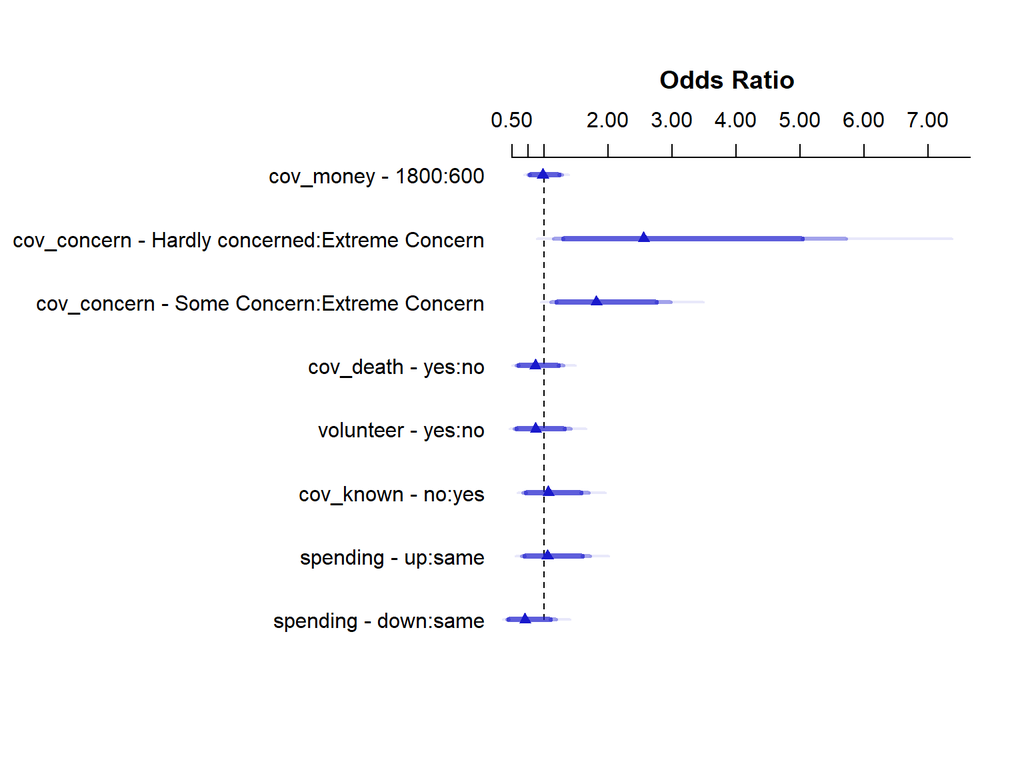

```r
plot(summary(m1lrm))
```

The plot of effect sizes for the main effects model is shown above. This plot appears to indicate that reducing COVID-19 concern actually increases the odds of the individual being vaccinated. Having some concern is associated with 1.81 times the likelihood of being vaccinated versus extreme concern. Additionally, someone that is hardly concerned with COVID-19 2.55 times the odds of being vaccinated than someone that is extremely concerned with COVID-19.

### 9.5.1 ROC curve

Here I am creating a plot displaying the ROC curve. The model produces a C-statistic of 0.61, which is not very convincing. This value suggests that the model hardly performs better than random guessing.

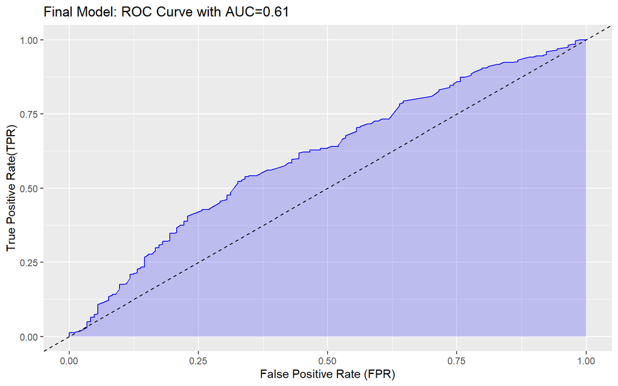

```r
prob <- predict(m1lrm, type = "fitted")
pred <- prediction(prob, a_log_sh$vaxxed, label.ordering = c("yes", "no"))
perf <- performance(pred, measure = "tpr", x.measure = "fpr")
auc <- performance(pred, measure = "auc")

auc <- round(auc@y.values[[1]],3)
roc.data <- data.frame(fpr=unlist(perf@x.values),
                       tpr=unlist(perf@y.values),
                       model="GLM")

ggplot(roc.data, aes(x=fpr, ymin=0, ymax=tpr)) +
  geom_ribbon(alpha=0.2, fill = "blue") +
  geom_line(aes(y=tpr), col = "blue") +
  geom_abline(intercept = 0, slope = 1, lty = "dashed") +
  labs(title = paste0("Final Model: ROC Curve with AUC=", auc),
       x = "False Positive Rate (FPR)",
       y = "True Positive Rate(TPR)")
```

### 9.5.2 Nagelkerke R-square and C-statistic

```r
validate(m1lrm)
```

```
          index.orig training   test optimism index.corrected  n
Dxy           0.2209   0.2610 0.1753   0.0856          0.1353 40
R2            0.0409   0.0648 0.0281   0.0367          0.0042 40
Intercept     0.0000   0.0000 0.2676  -0.2676          0.2676 40
Slope         1.0000   1.0000 0.6435   0.3565          0.6435 40
Emax          0.0000   0.0000 0.1502   0.1502          0.1502 40
D             0.0273   0.0449 0.0180   0.0270          0.0003 40
U            -0.0043  -0.0043 0.0054  -0.0097          0.0054 40
Q             0.0316   0.0492 0.0126   0.0367         -0.0051 40
B             0.2064   0.2013 0.2100  -0.0088          0.2152 40
g             0.4343   0.5521 0.3476   0.2045          0.2298 40
gp            0.0876   0.1073 0.0708   0.0365          0.0511 40
```

# 10 10. Discussion

For this project, my linear and logistic regression sought to answer 2 questions. Using linear regression, how well can we predict the weight of HRS respondents based on smoking and drinking habits? Using logistic regression, how well are we able to determine COVID-19 vaccination status of HRS respondents based on how COVID-19 has affected their lives?

For this project, finding and cleaning data was much harder than I expected. It is extremely difficult to find a data set that I felt comfortable working with. It is such a big task having to sort through documentation of different data sets, only to deal with the problems that come with needing to clean data and alter your analysis because of how the data is. I wish I knew how hard it is to find a suitable dataset because I would’ve spent more time for this process and set myself up to have an easier time with the analysis. I also would have attempted to include a larger raw data set with variables that I can just simply not use for my models. The most confusing part of the project was figuring out how to incorporate multiple imputation. I felt that using this complicated the way I needed to code certain things. However, I feel like this was also the most important thing I learned from this project. Since every data set faces complications and doing complete case analysis is unrealistic, knowing how to impute data seems really important and applicable.

# 11 11. Affirmation

I am certain that it is completely appropriate for these data to be shared with anyone, without any conditions. There are no concerns about privacy or safety.

# 12 12. References

Data is obtained from the [Health and Retirement Study, HRS CORE 2020](https://hrsdata.isr.umich.edu/data-products/2020-hrs-core) public use data set. Health and Retirement Study is produced and distributed by the University of Michigan and funded by the National Institute on Aging (grant number NIA U01AG009740).